# Self-Driving Car Engineer Nanodegree

## Project: Build a Traffic Sign Recognition Classifier

In this notebook, a template is provided for you to implement your functionality in stages, which is required to successfully complete this project. If additional code is required that cannot be included in the notebook, be sure that the Python code is successfully imported and included in your submission if necessary.

In addition to implementing code, there is a writeup to complete. The writeup should be completed in a separate file, which can be either a markdown file or a pdf document. There is a [write up template](https://github.com/udacity/CarND-Traffic-Sign-Classifier-Project/blob/master/writeup_template.md) that can be used to guide the writing process. Completing the code template and writeup template will cover all of the [rubric points](https://review.udacity.com/#!/rubrics/481/view) for this project.

The [rubric](https://review.udacity.com/#!/rubrics/481/view) contains "Stand Out Suggestions" for enhancing the project beyond the minimum requirements. The stand out suggestions are optional. If you decide to pursue the "stand out suggestions", you can include the code in this Ipython notebook and also discuss the results in the writeup file.

> **Note:** Code and Markdown cells can be executed using the **Shift + Enter** keyboard shortcut. In addition, Markdown cells can be edited by typically double-clicking the cell to enter edit mode.

## Step 0: Load The Data

```python
# Load pickled data
import pickle
import tensorflow as tf
import numpy as np
import cv2
import pickle
from sklearn.utils import shuffle
from matplotlib import pyplot as plt

import tensorflow as tf
from sklearn.utils import shuffle
import cv2

data_dir = "../data/"


# TODO: Fill this in based on where you saved the training and testing data

training_file = data_dir + 'train.p'
validation_file= data_dir + 'valid.p'
testing_file =  data_dir + 'test.p'
DEBUG = 1

seed = 1
tf.set_random_seed(seed)


with open(training_file, mode='rb') as f:
    train = pickle.load(f)
with open(validation_file, mode='rb') as f:
    valid = pickle.load(f)
with open(testing_file, mode='rb') as f:
    test = pickle.load(f)

X_train, y_train = train['features'], train['labels']
X_valid, y_valid = valid['features'], valid['labels']
X_test, y_test = test['features'], test['labels']

if DEBUG:
    print('Training data size  ',type(X_train),X_train.shape,y_train.shape)
    print('Validation data size ',X_valid.shape,X_valid.shape)
    print('Testing  data size ',X_test.shape,y_test.shape)
```

```
Training data size   <class 'numpy.ndarray'> (34799, 32, 32, 3) (34799,)
Validation data size  (4410, 32, 32, 3) (4410, 32, 32, 3)
Testing  data size  (12630, 32, 32, 3) (12630,)
```

## Step 1: Dataset Summary & Exploration

The pickled data is a dictionary with 4 key/value pairs:

- `'features'` is a 4D array containing raw pixel data of the traffic sign images, (num examples, width, height, channels).
- `'labels'` is a 1D array containing the label/class id of the traffic sign. The file `signnames.csv` contains id -> name mappings for each id.
- `'sizes'` is a list containing tuples, (width, height) representing the original width and height the image.
- `'coords'` is a list containing tuples, (x1, y1, x2, y2) representing coordinates of a bounding box around the sign in the image. **THESE COORDINATES ASSUME THE ORIGINAL IMAGE. THE PICKLED DATA CONTAINS RESIZED VERSIONS (32 by 32) OF THESE IMAGES**

Complete the basic data summary below. Use python, numpy and/or pandas methods to calculate the data summary rather than hard coding the results. For example, the [pandas shape method](http://pandas.pydata.org/pandas-docs/stable/generated/pandas.DataFrame.shape.html) might be useful for calculating some of the summary results.

### Provide a Basic Summary of the Data Set Using Python, Numpy and/or Pandas

```python
### Replace each question mark with the appropriate value.
### Use python, pandas or numpy methods rather than hard coding the results
import pandas as pd
import tensorflow as tf
# TODO: Number of training examples
n_train = X_train.shape[0]

# TODO: Number of validation examples
n_validation = X_valid.shape[0]

# TODO: Number of testing examples.
n_test = X_test.shape[0]

# TODO: What's the shape of an traffic sign image?
# image_shape = (X_train.shape[1],X_train.shape[2],X_train.shape[3])
image_shape = X_train[0].shape

# TODO: How many unique classes/labels there are in the dataset.

DEBUG = 1

seed = 1
tf.set_random_seed(seed)

csv_data = pd.read_csv('signnames.csv')

csv = {'ClassId': csv_data['ClassId'], 'SignName':csv_data['SignName']}

def get_info(dic,index):
    if index >= 0 and index <= len(dic['ClassId']):
        return dic['ClassId'][index], dic['SignName'][index]

n_classes = len(csv_data['ClassId'])

if DEBUG:
    print("Number of training examples =", n_train)
    print("Number of testing examples =", n_test)
    print("Image data shape =", image_shape)
    print("Number of classes =", n_classes)
```

```
Number of training examples = 34799
Number of testing examples = 12630
Image data shape = (32, 32, 3)
Number of classes = 43
```

### Include an exploratory visualization of the dataset

Visualize the German Traffic Signs Dataset using the pickled file(s). This is open ended, suggestions include: plotting traffic sign images, plotting the count of each sign, etc.

The [Matplotlib](http://matplotlib.org/) [examples](http://matplotlib.org/examples/index.html) and [gallery](http://matplotlib.org/gallery.html) pages are a great resource for doing visualizations in Python.

**NOTE:** It's recommended you start with something simple first. If you wish to do more, come back to it after you've completed the rest of the sections. It can be interesting to look at the distribution of classes in the training, validation and test set. Is the distribution the same? Are there more examples of some classes than others?

```
38
(34799,)
44
43
{0: 180, 1: 1980, 2: 2010, 3: 1260, 4: 1770, 5: 1650, 6: 360, 7: 1290, 8: 1260, 9: 1320, 10: 1800, 11: 1170, 12: 1890, 13: 1920, 14: 690, 15: 540, 16: 360, 17: 990, 18: 1080, 19: 180, 20: 300, 21: 270, 22: 330, 23: 450, 24: 240, 25: 1350, 26: 540, 27: 210, 28: 480, 29: 240, 30: 390, 31: 690, 32: 210…
```

[figure not shown]

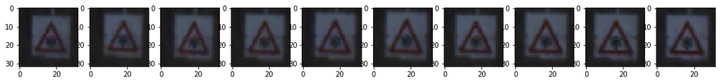

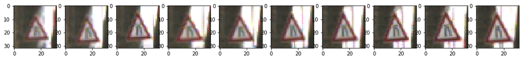

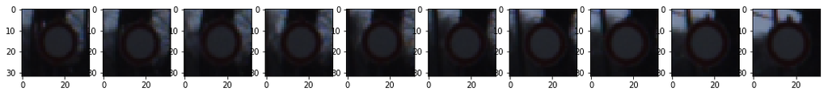

[figure not shown]

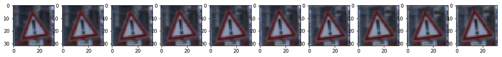

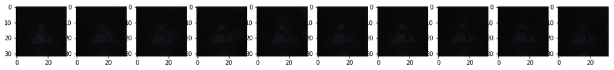

[figure not shown]

[figure not shown]

[figure not shown]

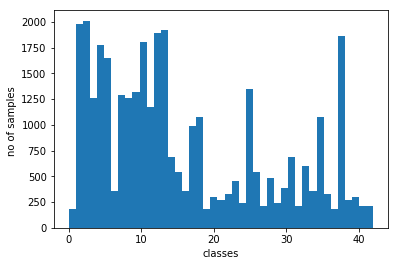

```
(38, 'Keep right')
```

```python
### Data exploration visualization code goes here.
### Feel free to use as many code cells as needed.
import matplotlib.pyplot as plt
import random
import numpy as np
%matplotlib inline
# Visualizations will be shown in the notebook.


index = random.randint(0, len(X_train))
image = X_train[index].squeeze()

if DEBUG:
    print(y_train[index])
    print(y_train.shape)

book = {}
counts,class_ids = np.histogram(y_train,bins=n_classes)

if DEBUG:
    print(len(class_ids))
    print(len(counts))

for i,count in enumerate(counts):
    book[(int(np.ceil(class_ids[i])))] = count


if DEBUG:
    print(book)


def get_imges_train(index):
    pos = 0
    list_imge = []
    for i in range(len(y_train)):
        if index == y_train[i]:
            # pos = i
            list_imge.append(X_train[i])
            if len(list_imge) == 10:
                break
    return list_imge

# for data visualization
for i in range(0,10):
    rand_int = np.random.randint(0,43)
    images = get_imges_train(rand_int)
    plt.figure(figsize=(18,16))
    for k, img in enumerate(images):
#         img = cv2.resize(img,(320,320))
        plt.subplot(1,10,k+1)
        plt.imshow(img)
#         cv2.imwrite(path_res + str(rand_int) + '_' +str(k + 1) + '_visual.jpg', img)


if DEBUG:
    plt.figure()
    plt.hist(y_train, bins=n_classes)
    plt.xlabel('classes')
    plt.ylabel('no of samples ')
    plt.figure(figsize=(1, 1))
    plt.show()

if DEBUG:
    print(get_info(csv,y_train[index]))
```

## Step 2: Design and Test a Model Architecture

Design and implement a deep learning model that learns to recognize traffic signs. Train and test your model on the [German Traffic Sign Dataset](http://benchmark.ini.rub.de/?section=gtsrb&subsection=dataset).

The LeNet-5 implementation shown in the classroom at the end of the CNN lesson is a solid starting point. You'll have to change the number of classes and possibly the preprocessing, but aside from that it's plug and play!

With the LeNet-5 solution from the lecture, you should expect a validation set accuracy of about 0.89. To meet specifications, the validation set accuracy will need to be at least 0.93. It is possible to get an even higher accuracy, but 0.93 is the minimum for a successful project submission.

There are various aspects to consider when thinking about this problem:

- Neural network architecture (is the network over or underfitting?)
- Play around preprocessing techniques (normalization, rgb to grayscale, etc)
- Number of examples per label (some have more than others).
- Generate fake data.

Here is an example of a [published baseline model on this problem](http://yann.lecun.com/exdb/publis/pdf/sermanet-ijcnn-11.pdf). It's not required to be familiar with the approach used in the paper but, it's good practice to try to read papers like these.

### Pre-process the Data Set (normalization, grayscale, etc.)

Minimally, the image data should be normalized so that the data has mean zero and equal variance. For image data, `(pixel - 128)/ 128` is a quick way to approximately normalize the data and can be used in this project.

Other pre-processing steps are optional. You can try different techniques to see if it improves performance.

Use the code cell (or multiple code cells, if necessary) to implement the first step of your project.

```
 Starting : Type of the X_train before  <class 'numpy.ndarray'> (32, 32, 3)
 Starting : Type of the X_train before  <class 'numpy.ndarray'> (32, 32, 3)
before augmentation
(34799, 32, 32, 3) (34799,) (32, 32, 3) ()
after
(83279, 32, 32, 1) (83279,) (32, 32, 1) ()
 Ending : Type of the X_train before  <class 'numpy.ndarray'> (32, 32, 1)
 Ending : Type of the X-test before  <class 'numpy.ndarray'> (32, 32, 1)
 Ending : Type of the X_valid before  <class 'numpy.ndarray'> (32, 32, 1)
```

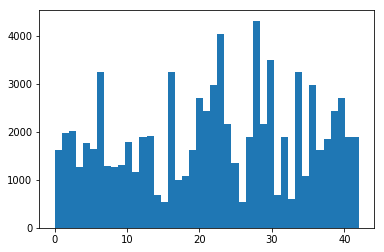

```python
### Preprocess the data here. It is required to normalize the data. Other preprocessing steps could include
### converting to grayscale, etc.
### Feel free to use as many code cells as needed.
### Preprocess the data here. It is required to normalize the data. Other preprocessing steps could include
### converting to grayscale, etc.
### Feel free to use as many code cells as needed.
import tensorflow as tf
from sklearn.utils import shuffle
import cv2

print(' Starting : Type of the X_train before ',type(X_train),X_train[0].shape)
X_train, y_train = shuffle(X_train, y_train)


def normalize(img):
    mean = np.mean(img,axis=0)
    std = np.std(img,axis=0)
    norm = (img - mean)/(std + 0.00000001)
    return norm

def get_gray(img):
    gray = cv2.cvtColor(img,cv2.COLOR_BGR2GRAY)
    return gray


def apply_affine(img, a1, a2, a3, a4):
    rows, cols = img.shape[0], img.shape[1]
    offset = int(0.05*cols/100)   # np.random.randint(1,10)
    # pts1 = np.float32([[0, 0], [cols - 1, 0], [0, rows - 1], [cols - 1, rows - 1]])
    pts1 = np.float32([[offset, offset], [cols - 1 -offset, offset], [offset, rows - 1 -offset], [cols - 1- offset, rows - 1 -offset]])

    alpha1 = a1
    beta1 = a2
    alpha2 = a3
    beta2 = a4
    pts2 = np.float32([[int(alpha1 * cols), int(beta1 * rows)], [int((1 - alpha1) * cols), int(beta2 * rows)],
                       [int(alpha2 * cols), int((1 - beta1) * rows)],
                       [int((1 - alpha2) * cols), int((1 - beta2) * rows)]])

    M = cv2.getPerspectiveTransform(pts1, pts2)
    warped = cv2.warpPerspective(img, M, (cols, rows))
    return warped

def rotate_bound(image, angle,scale=1.0):
    # grab the dimensions of the image and then determine the
    # center
    (h, w) = image.shape[:2]
    (cX, cY) = (w // 2, h // 2)

    # grab the rotation matrix (applying the negative of the
    # angle to rotate clockwise), then grab the sine and cosine
    # (i.e., the rotation components of the matrix)
    M = cv2.getRotationMatrix2D((cX, cY), -angle, scale)
    cos = np.abs(M[0, 0])
    sin = np.abs(M[0, 1])

    # compute the new bounding dimensions of the image
    nW = int((h * sin) + (w * cos))
    nH = int((h * cos) + (w * sin))

    # adjust the rotation matrix to take into account translation
    M[0, 2] += (nW / 2) - cX
    M[1, 2] += (nH / 2) - cY

    # perform the actual rotation and return the image
    return cv2.warpAffine(image, M, (nW, nH))


def salt_and_pepper(img,tpoints= 10000):
    rx = np.random.randint(0,img.shape[0]-1,tpoints)
    ry = np.random.randint(0, img.shape[1] - 1, tpoints)
    img[rx[:tpoints//2],ry[:tpoints//2]] = 255
    img[rx[tpoints//2:], ry[tpoints//2:]] = 0
    return img


def gen_data(img):
    (rows, cols) = img.shape[:2]
    data_augmented = []
    ## blur the image
    #     data_augmented.append(cv2.GaussianBlur(img,(7,7),sigmaX=2,sigmaY=2))
    # apply rotation in angle steps from -4*angle_steps to 4*angle_steps
    angle_steps = 5
    #     for i in range(0,5):
    #     data_augmented.append(cv2.resize(rotate_bound(img,(3)*angle_steps),(rows,cols)))
    #     data_augmented.append(cv2.resize(rotate_bound(img, (-3)* angle_steps),(rows,cols)))
    # flip images
    # data_augmented.append()

    data_augmented.append(img.copy())
    data_augmented.append(cv2.resize(cv2.flip(img, 0), (rows, cols)))
    data_augmented.append(cv2.resize(cv2.flip(img, 1), (rows, cols)))
    data_augmented.append(cv2.resize(cv2.flip(img, -1), (rows, cols)))

    # apply affine transformations
    #     data_augmented.append(apply_affine(img, 0.1, 0.1, 0.1, 0.1))  ## as good as rescaled version
    param = [0.05, 0.05, 0.05, 0.05]
    for i in range(0, 4):
        temp = param.copy()
        for j in range(0, 1):
            offset = (j + 1) * 0.1
            temp[i] = param[i] + offset #  + (np.random.randint(1,10)/100)
            # print(temp)
            data_augmented.append(apply_affine(img, temp[0], temp[1], temp[2], temp[3]))

    data_augmented.append(salt_and_pepper(img, 100))
    return data_augmented



def data_augmentation(xsamples, ysamples):
    data_aug_tempx = []
    data_aug_tempy = []
    for i in range(len(xsamples)):
        class_id = []
        aug_list = []
        if book[ysamples[i]] < 500:
            aug_list = gen_data(xsamples[i])
        else:
            aug_list.append(xsamples[i])

        class_id = ysamples[i]
        tempy = [class_id for i in range(len(aug_list))]
        aug_list = [np.expand_dims(img, axis=2) for img in aug_list]
        data_aug_tempx.append(aug_list)
        data_aug_tempy.append(tempy)
    sample_x = np.concatenate(tuple(data_aug_tempx))
    sample_y = np.concatenate(tuple(data_aug_tempy))
    return sample_x, sample_y

print(' Starting : Type of the X_train before ', type(X_train), X_train[0].shape)
X_train, y_train = shuffle(X_train, y_train)

## pre-porcessing
X_train1 = np.array([normalize(get_gray(X_train[i])) for i in range(len(X_train))])
X_valid = np.array([np.expand_dims(normalize(get_gray(X_valid[i])), axis=2) for i in range(len(X_valid))])
X_test = np.array([np.expand_dims(normalize(get_gray(X_test[i])), axis=2) for i in range(len(X_test))])

print('before augmentation')
print(X_train.shape, y_train.shape, X_train[0].shape, y_train[0].shape)
X_train, y_train = data_augmentation(X_train1, y_train)

print('after ')
print(X_train.shape, y_train.shape, X_train[0].shape, y_train[0].shape)

print(' Ending : Type of the X_train before ', type(X_train), X_train[0].shape)
print(' Ending : Type of the X-test before ', type(X_test), X_test[0].shape)
print(' Ending : Type of the X_valid before ', type(X_valid), X_valid[0].shape)

X_train, y_train = shuffle(X_train, y_train)
if DEBUG:
    plt.hist(y_train, bins=n_classes)
    plt.figure(figsize=(1, 1))
    plt.show()
```

### Model Architecture

[figure not shown]

```python
### Define your architecture here.
### Feel free to use as many code cells as needed.

X_train, y_train = shuffle(X_train, y_train)
plt.imshow(X_train[0].squeeze(),cmap='gray')

EPOCHS = 50
BATCH_SIZE = 128


keep_prob1 = 0.4
keep_prob1 = tf.placeholder(tf.float32,())

from tensorflow.contrib.layers import flatten


def conv2d(input, shape, mean, std):
    conv_W = tf.Variable(tf.truncated_normal(shape=shape, mean=mean, stddev=std))
    conv_b = tf.Variable(tf.zeros(shape[-1]))
    conv = tf.nn.conv2d(input, conv_W, strides=[1, 1, 1, 1], padding='VALID') + conv_b
    return conv


def fully_connected(input, shape, mean, std):
    W = tf.Variable(tf.truncated_normal(shape=shape, mean=mean, stddev=std))
    b = tf.Variable(tf.zeros(shape[-1]))
    return tf.matmul(input, W) + b


def activation(input):
    return tf.nn.relu(input)


def LeNet_Modified(x):
    # Arguments used for tf.truncated_normal, randomly defines variables for the weights and biases for each layer
    mu = 0
    sigma = 0.1

    # Feature extraction part
    # Layer 1: Convolutional. Input = 32x32x1. Output = 28x28x5.
    conv1 = conv2d(x, (5, 5, 1, 5), mu, sigma)
    # Input = 28x28x5. Output = 24x24x15.
    conv2 = conv2d(conv1, (5, 5, 5, 15), mu, sigma)
    conv2 = activation(conv2)
    # Input = 24x24x15. Output = 12x12x15.
    conv2 = tf.nn.max_pool(conv2, ksize=[1, 2, 2, 1], strides=[1, 2, 2, 1], padding='VALID')

    # Input = 12x12x15. Output = 10x10x30.
    conv3 = conv2d(conv2, (3, 3, 15, 30), mu, sigma)
    # Input = 10x10x30. Output = 8x8x48.
    conv4 = conv2d(conv3, (3, 3, 30, 48), mu, sigma)
    conv4 = activation(conv4)
    # Input = 8x8x28. Output = 4x4x48.
    conv4 = tf.nn.max_pool(conv4, ksize=[1, 2, 2, 1], strides=[1, 2, 2, 1], padding='VALID')

    # Input = 4x4x48. Output = 2x2x64.
    conv5 = conv2d(conv4, (3, 3, 48, 64), mu, sigma)
    conv5 = activation(conv5)

    f = flatten(conv5)

    # Classification part
    fc1 = fully_connected(f, (256, 128), mu, sigma)
    fc1 = activation(fc1)
    fc1 = tf.nn.dropout(fc1, keep_prob1)

    fc2 = fully_connected(fc1, (128, 80), mu, sigma)
    fc2 = activation(fc2)
    fc2 = tf.nn.dropout(fc2, keep_prob1)

    fc3 = fully_connected(fc2, (80, 43), mu, sigma)
    fc3 = activation(fc3)
    # fc3 = tf.nn.dropout(fc3, 0.5)

    # Activation.
    # fc2 = tf.nn.relu(fc2)

    # fc3_W = tf.Variable(tf.truncated_normal(shape=(100, n_classes), mean=mu, stddev=sigma))
    # fc3_b = tf.Variable(tf.zeros(n_classes))
    # fc3 = tf.matmul(fc2, fc2_W) + fc2_b
    # Activation.
    logits = fc3

    # logits = fc3

    # logits = tf.nn.relu(fc2)
    # print('Shape of logit',logits.shape)
    return logits

def LeNet(x):
    # Arguments used for tf.truncated_normal, randomly defines variables for the weights and biases for each layer
    mu = 0
    sigma = 0.1

    # TODO: Layer 1: Convolutional. Input = 32x32x1. Output = 28x28x6.
    w1 = tf.Variable(tf.truncated_normal([5, 5, 1, 6]))
    b1 = tf.Variable(tf.zeros([6]))

    conv1 = tf.nn.conv2d(x,w1,[1,1,1,1],padding='VALID')
    conv1 = tf.nn.bias_add(conv1, b1)
    # TODO: Activation.
    conv1 = tf.nn.relu(conv1)
    # TODO: Pooling. Input = 28x28x6. Output = 14x14x6.
    conv1 = tf.nn.max_pool(conv1,ksize=[1,2,2,1],strides=[1,2,2,1],padding='SAME')
    # TODO: Layer 2: Convolutional. Output = 10x10x16.

    w2 = tf.Variable(tf.truncated_normal([5, 5, 6, 16]))
    b2 = tf.Variable(tf.zeros([16]))
    conv2 = tf.nn.conv2d(conv1,w2,strides=[1,1,1,1],padding='VALID')
    # TODO: Activation.
    conv2 = tf.nn.relu(conv2)
    # TODO: Pooling. Input = 10x10x16. Output = 5x5x16.
    conv2 = tf.nn.max_pool(conv2,ksize=[1,2,2,1],strides=[1,2,2,1],padding='SAME')
    # TODO: Flatten. Input = 5x5x16. Output = 400.
    flatten = tf.contrib.layers.flatten(conv2)
    # TODO: Layer 3: Fully Connected. Input = 400. Output = 120.
    fc1 = tf.contrib.layers.fully_connected(flatten,120,activation_fn=None)
    # TODO: Activation.
    fc1 = tf.nn.relu(fc1)
    fc1    = tf.nn.dropout(fc1,keep_prob=keep_prob1)
    # TODO: Layer 4: Fully Connected. Input = 120. Output = 84.
    fc2 = tf.contrib.layers.fully_connected(fc1,84,activation_fn=None)
    # TODO: Activation.
    fc2 = tf.nn.relu(fc2)
    # TODO: Layer 5: Fully Connected. Input = 84. Output = 10.
    logits = tf.contrib.layers.fully_connected(fc2,43,activation_fn=None)
    return logits
```

### Train, Validate and Test the Model

A validation set can be used to assess how well the model is performing. A low accuracy on the training and validation sets imply underfitting. A high accuracy on the training set but low accuracy on the validation set implies overfitting.

```python
### Train your model here.
### Calculate and report the accuracy on the training and validation set.
### Once a final model architecture is selected,
### the accuracy on the test set should be calculated and reported as well.
### Feel free to use as many code cells as needed.

x = tf.placeholder(tf.float32, (None, 32, 32, 1))
y = tf.placeholder(tf.int32, (None))
one_hot_y = tf.one_hot(y, n_classes)  # one hot encoding for output labels
keep_prob = tf.placeholder(
    tf.float32)  # defining the dropout probability after fully connected layer in the architecture
print('Variables initialized successfully')

rate = 0.0001  # learning rate
```

```
Variables initialized successfully
```

```python
logits = LeNet_Modified(x)
cross_entropy = tf.nn.softmax_cross_entropy_with_logits(labels=one_hot_y, logits=logits)
loss_operation = tf.reduce_mean(cross_entropy)
optimizer = tf.train.AdamOptimizer(learning_rate = rate)
training_operation = optimizer.minimize(loss_operation)
```

```python
### Once a final model architecture is selected,
correct_prediction = tf.equal(tf.argmax(logits, 1), tf.argmax(one_hot_y, 1))
accuracy_operation = tf.reduce_mean(tf.cast(correct_prediction, tf.float32))
saver = tf.train.Saver()

def evaluate(X_data, y_data):
    num_examples = len(X_data)
    total_accuracy = 0
    total_loss = 0
    sess = tf.get_default_session()
    for offset in range(0, num_examples, BATCH_SIZE):
        batch_x, batch_y = X_data[offset:offset + BATCH_SIZE], y_data[offset:offset + BATCH_SIZE]
        accuracy, loss = sess.run([accuracy_operation, loss_operation],
                                  feed_dict={x: batch_x, y: batch_y, keep_prob1: 1})
        total_accuracy += (accuracy * len(batch_x))
        total_loss += (loss * len(batch_x))  # getting the total loss to plot a graph later
    return total_accuracy / num_examples, total_loss / num_examples

xtrain, ytrain = shuffle(X_train, y_train)
```

```
Training...

EPOCH 1 ...
Validation Accuracy = 0.016

EPOCH 2 ...
Validation Accuracy = 0.032

EPOCH 3 ...
Validation Accuracy = 0.076

EPOCH 4 ...
Validation Accuracy = 0.239

EPOCH 5 ...
Validation Accuracy = 0.368

EPOCH 6 ...
Validation Accuracy = 0.510

EPOCH 7 ...
Validation Accuracy = 0.609

EPOCH 8 ...
Validation Accuracy = 0.659

EPOCH 9 ...
Validation Accuracy = 0.741

EPOCH 10 ...
Validation Accuracy = 0.797

EPOCH 11 ...
Validation Accuracy = 0.826

EPOCH 12 ...
Validation Accuracy = 0.849

EPOCH 13 ...
Validation Accuracy = 0.859
```

[output cut: 96 more lines]

```

EPOCH 46 ...
Validation Accuracy = 0.952

EPOCH 47 ...
Validation Accuracy = 0.954

EPOCH 48 ...
Validation Accuracy = 0.954

EPOCH 49 ...
Validation Accuracy = 0.953

EPOCH 50 ...
Validation Accuracy = 0.954
```

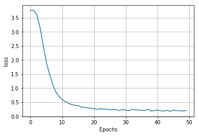

```
Model saved
```

```python
import tensorflow as tf
CHECK_POINT_PATH = r'./check_points'

with tf.Session() as sess:
    sess.run(tf.global_variables_initializer())
    num_examples = len(X_train)

    print("Training...")
    print()
    loss_Acc = []
    for i in range(EPOCHS):
        X_train, y_train = shuffle(X_train, y_train)
        # print(y_train)
        for offset in range(0, num_examples, BATCH_SIZE):
            end = offset + BATCH_SIZE
            batch_x, batch_y = X_train[offset:end], y_train[offset:end]
            sess.run(training_operation, feed_dict={x: batch_x, y: batch_y, keep_prob1: 0.5})

        validation_accuracy, loss_acc = evaluate(X_valid, y_valid)

        print("EPOCH {} ...".format(i + 1))
        loss_Acc.append(loss_acc)
        print("Validation Accuracy = {:.3f}".format(validation_accuracy))
        print()
    if DEBUG:
        plt.plot(range(0, EPOCHS), loss_Acc)
        plt.ylabel('loss')
        plt.xlabel('Epochs')
        plt.grid(True)
        plt.show()
    saver.save(sess, CHECK_POINT_PATH + '/traffic_sign_0.5')
    print("Model saved")
```

```python
# testing the model for test images
CHECK_POINT_PATH = r'./check_points'

with tf.Session() as ss:
    ss.run(tf.global_variables_initializer())
    saver.restore(ss,CHECK_POINT_PATH + '/traffic_sign_0.5')
    train_accuracy,train_loss = evaluate(X_train,y_train)
    valid_accuracy,valid_loss = evaluate(X_valid,y_valid)
    test_accuracy,test_loss = evaluate(X_test,y_test)
    print(' Train images accuracy is ',train_accuracy)
    print(' Validation images accuracy is ',valid_accuracy)
    print(' Test images accuracy is ',test_accuracy)
```

```
INFO:tensorflow:Restoring parameters from ./check_points/traffic_sign_0.5
 Train images accuracy is  0.920099905118
 Validation images accuracy is  0.953968253995
 Test images accuracy is  0.925969913085
```

## Step 3: Test a Model on New Images

To give yourself more insight into how your model is working, download at least five pictures of German traffic signs from the web and use your model to predict the traffic sign type.

You may find `signnames.csv` useful as it contains mappings from the class id (integer) to the actual sign name.

### Load and Output the Images

```
./german_traffic_images/28.jpg
./german_traffic_images/15.jpg
./german_traffic_images/14.jpg
./german_traffic_images/36.jpg
./german_traffic_images/.ipynb_checkpoints
./german_traffic_images/33.jpg
./german_traffic_images/2.jpg
./german_traffic_images/24.jpg
./german_traffic_images/22.jpg
./german_traffic_images/25.jpg
Images before pre-processing
Images after pre-processing ie. converting to gray and mean normalization
```

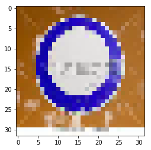

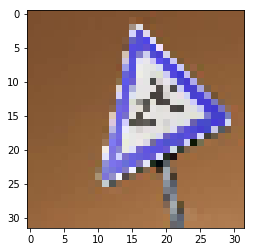

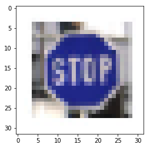

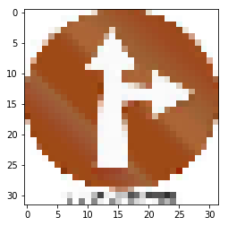

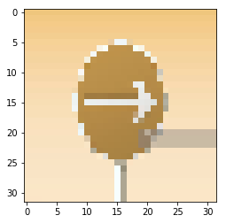

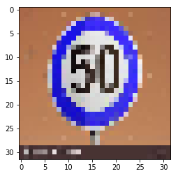

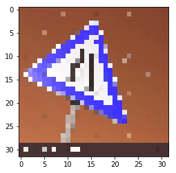

[figure not shown]

[figure not shown]

[figure not shown]

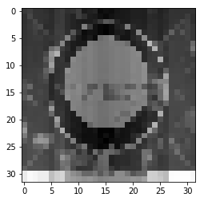

[figure not shown]

[6 more figures not shown]

```python
### Load the images and plot them here.
### Feel free to use as many code cells as needed.
### Load the images and plot them here.
### Feel free to use as many code cells as needed.
TRAFFIC_IMAGE = r'./german_traffic_images'

import os
import cv2
import numpy as np
from matplotlib import pyplot as plt

images_list = os.listdir(TRAFFIC_IMAGE)

xtest = []
ytest =[]
imagesList = []

for path in images_list:
    full_path = TRAFFIC_IMAGE +r'/' +  os.path.basename(path)
    print(full_path)
    img = cv2.imread(full_path)
    if img is not None:
        img = cv2.resize(img,(32,32))
        str_splits = (os.path.basename(path)).split('.')
        xtest.append(img)
        ytest.append(int(str_splits[0]))

xtest = np.array(xtest)
ytest = np.array(ytest)


print('Images before pre-processing')
plt.figure(1)
for i in range(len(xtest)):
    plt.figure(i)
    plt.imshow(xtest[i].squeeze())

xtest = np.array([ np.expand_dims(normalize(get_gray(xtest[i])),axis =2) for i in range(len(xtest))])

print('Images after pre-processing ie. converting to gray and mean normalization')
plt.figure(2)
for i in range(len(xtest)):
    plt.figure(len(xtest) + i)
    plt.imshow(xtest[i].squeeze(),cmap='gray')
```